# da3-a2-detailed

Abigail Chen

## Research Question

The task is to help a company operating small and mid-size apartments hosting 2-6 guests. The company is set to price their new apartments not on the market and the task is to help them make business decisions. The goal is to help them build a price prediction model.

## Introduction

This project is a linear regression analysis on data about Airbnb rentals in Hawaii, USA. The dataset is taken from **Inside Airbnb Website** (http://insideairbnb.com/get-the-data.html). The relationship between price and room type, neighborhood along with other parameters will be used. The raw dataset has 24,294 observations.

## Exploratory Data Analysis

First, the structure of the data was analysed. Then the various data types were changed to categorical from character format. The price had outliers and its distribution was right skewed. The “ln” was used and outliers were also removed from the list. So, for modeling our dependent variable was ln_price.

## Main model Linear Regression : lm

$$lnPrices=\beta_0+\beta_1(roomtype)$$
$$lnPrices=\beta_0+\beta_1(neighbourhoodGroup)$$
$$lnPrices=\beta_0+\beta_1(minimumNights)$$

$$lnPrices=\beta_0+\beta_1(roomtype)+\beta_2(neighbourhoodGroup)$$

$$lnPrices=\beta_0+\beta_1(roomtype)+\beta_2(minimumNights)$$

$$lnPrices=\beta_0+\beta_1(neighbourhoodGroup)+\beta_2(minimumNights)$$

## External Validity

The data set was divided randomly into train and test in 80-20 percent ratio.

## Alternative model: LASSO

Lasso regression is a classification algorithm that uses shrinkage in simple and sparse models(i.e model with fewer parameters). In Shrinkage, data values are shrunk towards a central point like the mean. Lasso regression is a regularized regression algorithm that performs L1 regularization which adds penalty equal to the absolute value of the magnitude of coefficients.

“LASSO” stands for Least Absolute Shrinkage and Selection Operator. Lasso regression is good for models showing high levels of multicollinearity or when you want to automate certain parts of model selection i.e variable selection or parameter elimination.” so formula ln_price ~. we dont need preprocess and feature selaction. results of the Lasso model were not better but were close to Model 7 . Additional **source**(https://www.geeksforgeeks.org/lasso-regression-in-r-programming/).

## Conclusion

# Data Cleaning

## Looking at column names

There are 18 columns initially

```r
names(df)
```

```
##  [1] "id"                             "name"
##  [3] "host_id"                        "host_name"
##  [5] "neighbourhood_group"            "neighbourhood"
##  [7] "latitude"                       "longitude"
##  [9] "room_type"                      "price"
## [11] "minimum_nights"                 "number_of_reviews"
## [13] "last_review"                    "reviews_per_month"
## [15] "calculated_host_listings_count" "availability_365"
## [17] "number_of_reviews_ltm"          "license"
```

## Initial Check:

Removing the data we don’t need. We dont need to look at : “id” , “name” , “host_id” , “host_name”, ‘longitude’, ‘latitude’,‘last_review’.

```r
df = df[,c("price" , "neighbourhood_group" , "neighbourhood" , "minimum_nights",
           'number_of_reviews', 'reviews_per_month','calculated_host_listings_count',
           'availability_365','number_of_reviews_ltm','license','room_type')]
names(df)
```

```
##  [1] "price"                          "neighbourhood_group"
##  [3] "neighbourhood"                  "minimum_nights"
##  [5] "number_of_reviews"              "reviews_per_month"
##  [7] "calculated_host_listings_count" "availability_365"
##  [9] "number_of_reviews_ltm"          "license"
## [11] "room_type"
```

## Looking at the structure

```r
str(df)
```

```
## 'data.frame':    24294 obs. of  11 variables:
##  $ price                         : int  149 85 299 425 140 151 98 139 376 169 ...
##  $ neighbourhood_group           : chr  "Hawaii" "Hawaii" "Hawaii" "Kauai" ...
##  $ neighbourhood                 : chr  "South Kohala" "South Kona" "North Kona" "North Shore Kauai" ...
##  $ minimum_nights                : int  3 5 6 2 3 4 3 3 7 30 ...
##  $ number_of_reviews             : int  16 186 32 134 206 40 266 132 28 7 ...
##  $ reviews_per_month             : num  0.12 1.29 0.33 0.9 1.54 0.3 1.92 1.47 0.4 0.12 ...
##  $ calculated_host_listings_count: int  2 2 2 2 4 1 1 2 9 1 ...
##  $ availability_365              : int  193 253 189 231 120 276 172 218 237 120 ...
##  $ number_of_reviews_ltm         : int  6 18 12 26 27 12 36 19 4 0 ...
##  $ license                       : chr  "119-269-5808-01R" "" "" "540050300023" ...
##  $ room_type                     : chr  "Entire home/apt" "Entire home/apt" "Entire home/apt" "Entire home/apt" ...
```

## Fixing data types

Converting to factor format

```r
df$neighbourhood_group = as.factor(df$neighbourhood_group)

df$neighbourhood = as.factor(df$neighbourhood )

df$room_type = as.factor(df$room_type )

str(df)
```

```
## 'data.frame':    24294 obs. of  11 variables:
##  $ price                         : int  149 85 299 425 140 151 98 139 376 169 ...
##  $ neighbourhood_group           : Factor w/ 4 levels "Hawaii","Honolulu",..: 1 1 1 3 3 4 1 3 2 1 ...
##  $ neighbourhood                 : Factor w/ 30 levels "Central Oahu",..: 26 27 19 20 9 8 19 20 11 19 ...
##  $ minimum_nights                : int  3 5 6 2 3 4 3 3 7 30 ...
##  $ number_of_reviews             : int  16 186 32 134 206 40 266 132 28 7 ...
##  $ reviews_per_month             : num  0.12 1.29 0.33 0.9 1.54 0.3 1.92 1.47 0.4 0.12 ...
##  $ calculated_host_listings_count: int  2 2 2 2 4 1 1 2 9 1 ...
##  $ availability_365              : int  193 253 189 231 120 276 172 218 237 120 ...
##  $ number_of_reviews_ltm         : int  6 18 12 26 27 12 36 19 4 0 ...
##  $ license                       : chr  "119-269-5808-01R" "" "" "540050300023" ...
##  $ room_type                     : Factor w/ 4 levels "Entire home/apt",..: 1 1 1 1 3 1 1 1 1 1 ...
```

## License :

Changing license to binary category, assuming missing ones do not have a license.

```r
df$license[df$license != ''] = 1

df$license[df$license == ''] = 0

df$license = as.factor(df$license )

summary(df$license)
```

```
##     0     1
##  5544 18750
```

## Summary of the data

```r
summary(df)
```

```
##      price         neighbourhood_group              neighbourhood
##  Min.   :    0.0   Hawaii  :5237       Primary Urban Center:5110
##  1st Qu.:  153.0   Honolulu:7252       Lahaina             :3943
##  Median :  245.0   Kauai   :3456       Kihei-Makena        :3785
##  Mean   :  447.3   Maui    :8349       North Kona          :2191
##  3rd Qu.:  400.0                       North Shore Kauai   :1354
##  Max.   :25000.0                       Koloa-Poipu         :1237
##                                        (Other)             :6674
##  minimum_nights     number_of_reviews reviews_per_month
##  Min.   :   1.000   Min.   :  0.00    Min.   : 0.010
##  1st Qu.:   1.000   1st Qu.:  1.00    1st Qu.: 0.290
##  Median :   3.000   Median :  7.00    Median : 0.740
##  Mean   :   6.429   Mean   : 29.27    Mean   : 1.143
##  3rd Qu.:   5.000   3rd Qu.: 32.00    3rd Qu.: 1.620
##  Max.   :1000.000   Max.   :878.00    Max.   :21.210
##                                       NA's   :4964
##  calculated_host_listings_count availability_365 number_of_reviews_ltm
##  Min.   :  1.00                 Min.   :  0.0    Min.   :  0.000
##  1st Qu.:  2.00                 1st Qu.:101.0    1st Qu.:  0.000
##  Median : 14.00                 Median :213.0    Median :  3.000
##  Mean   : 62.65                 Mean   :190.5    Mean   :  9.694
##  3rd Qu.: 83.00                 3rd Qu.:279.0    3rd Qu.: 13.000
##  Max.   :439.00                 Max.   :365.0    Max.   :388.000
##
##  license             room_type
##  0: 5544   Entire home/apt:21961
##  1:18750   Hotel room     :   82
##            Private room   : 2216
##            Shared room    :   35
##
##
##
```

There are 4964 NAs in “reviews per month” since the number of missing reviews per month is very large, we will drop them from our data.

```r
df = na.omit(df)
```

## Analyzing Price

```r
summary(df$price)
```

```
##    Min. 1st Qu.  Median    Mean 3rd Qu.    Max.
##     0.0   147.0   224.0   345.5   350.0 25000.0
```

Here we can see a huge difference between 3rd quartile and max value.

### Visualizing the distribution of price:histogram

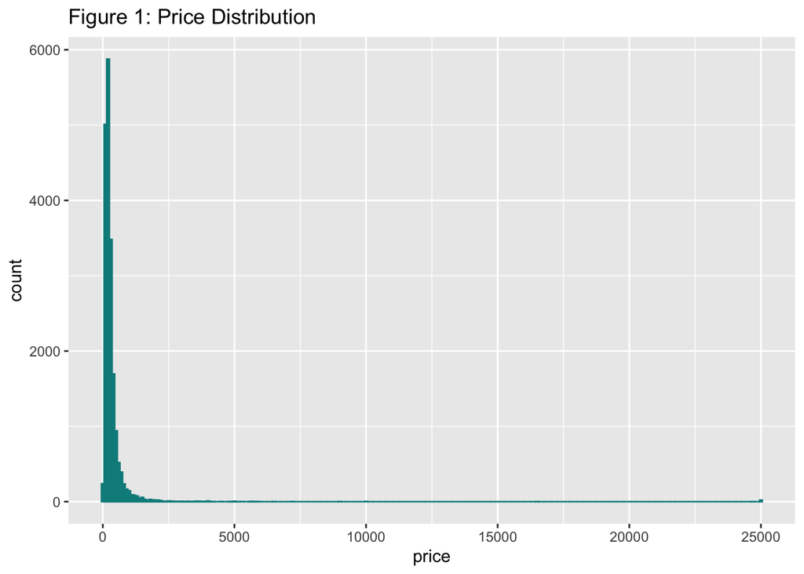

```r
ggplot(df, aes(x=price)) +
  geom_histogram(color="darkcyan", fill="darkcyan",binwidth=100) +
  ggtitle( "Figure 1: Price Distribution" )
```

Checking for outliers in the data.

### Taking ln of price

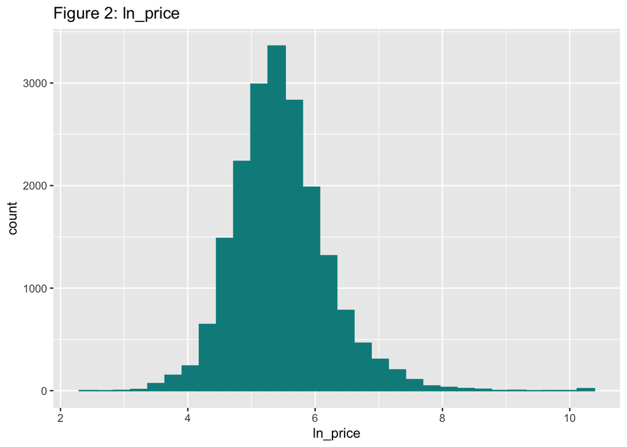

```r
df$ln_price = ln(df$price)

ggplot(df, aes(x=ln_price)) +
  geom_histogram(color="darkcyan", fill="darkcyan",bins = 30) +
   ggtitle( "Figure 2: ln_price" )
```

ln has turned it into a normal distribution

## removing the outliers

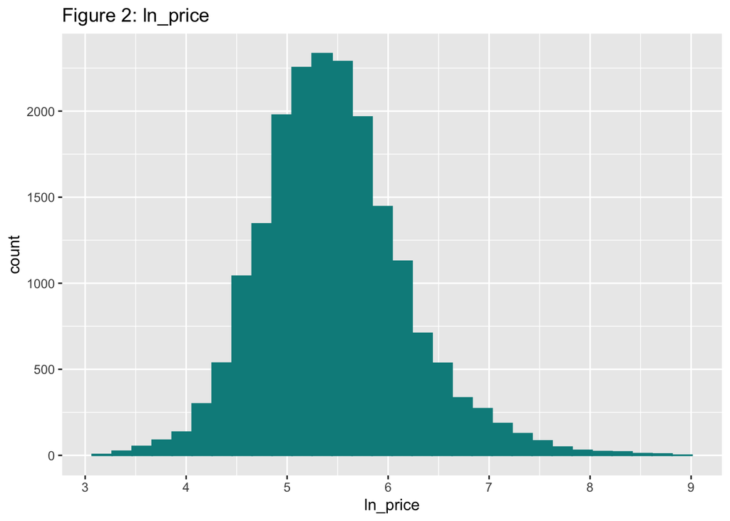

```r
df <- subset(df, ln_price>3 & ln_price<9 )

ggplot(df, aes(x=ln_price)) +
  geom_histogram(color="darkcyan", fill="darkcyan",bins = 30) +
   ggtitle( "Figure 2: ln_price" )
```

ln_price will be used for analysis instead of price.

## Analyzing minimum_nights

```r
summary(df$minimum_nights)
```

```
##    Min. 1st Qu.  Median    Mean 3rd Qu.    Max.
##    1.00    2.00    3.00    6.29    5.00 1000.00
```

### Histogram

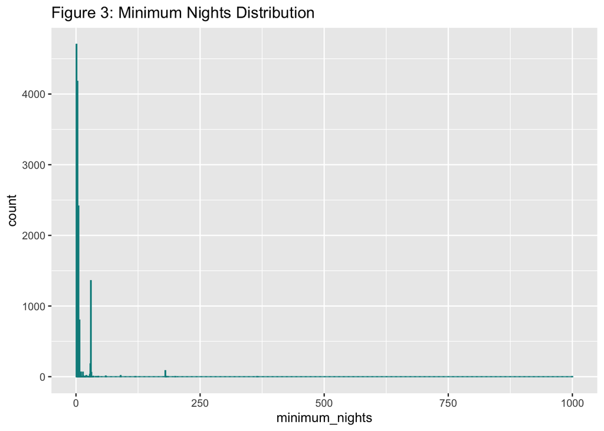

```r
ggplot(df, aes(x=minimum_nights)) +
  geom_histogram(color="darkcyan", fill="darkcyan", binwidth = 1) +
  ggtitle( "Figure 3: Minimum Nights Distribution" )
```

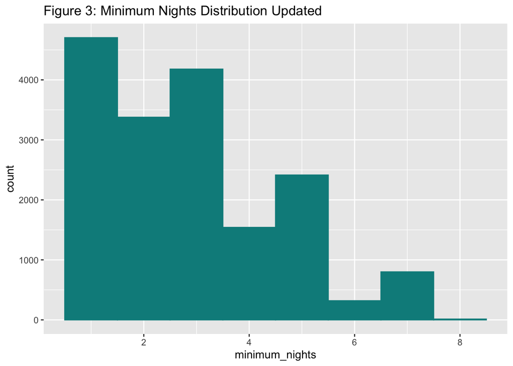

```r
df1 <- subset(df, minimum_nights<9)

ggplot(df1, aes(x=minimum_nights)) +
  geom_histogram(color="darkcyan", fill="darkcyan", binwidth = 1) +
  ggtitle( "Figure 3: Minimum Nights Distribution Updated" )
```

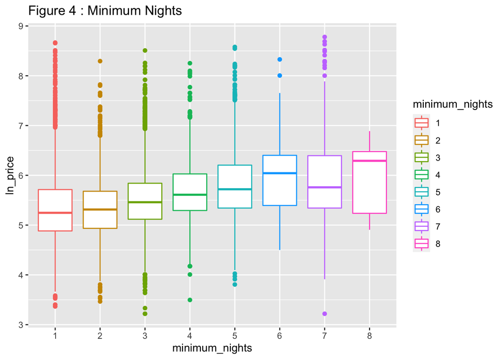

```r
## minimum night looks like a category
## changing the data type

df1$minimum_nights = as.factor(df1$minimum_nights)

ggplot(df1, aes(x=minimum_nights, y=ln_price, color = minimum_nights)) +
  geom_boxplot() +
  ggtitle("Figure 4 : Minimum Nights")
```

The price seems to increase with increase in minimum nights , plot and anova test shows it.

```r
ANOVAln_price_minimum_nights <- aov(ln_price ~ minimum_nights, data = df1)

summary(ANOVAln_price_minimum_nights)
```

```
##                   Df Sum Sq Mean Sq F value              Pr(>F)
## minimum_nights     7    680   97.19   228.5 <0.0000000000000002 ***
## Residuals      17338   7376    0.43
## ---
## Signif. codes:  0 '***' 0.001 '**' 0.01 '*' 0.05 '.' 0.1 ' ' 1
```

```r
df = df1
```

## Analyzing number_of_reviews

```r
summary(df$number_of_reviews)
```

```
##    Min. 1st Qu.  Median    Mean 3rd Qu.    Max.
##    1.00    4.00   14.00   37.47   45.00  878.00
```

### Histogram

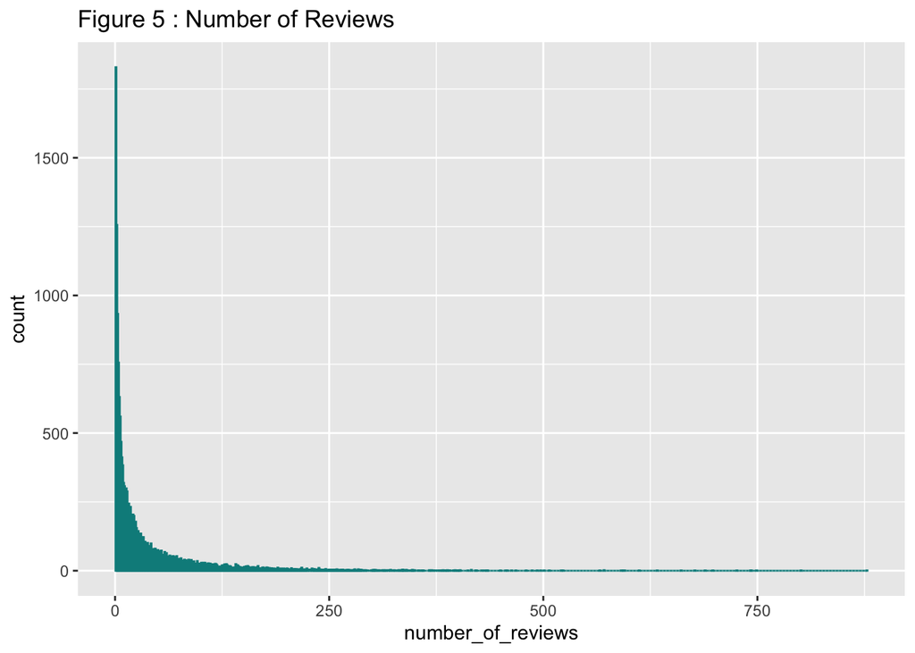

```r
ggplot(df, aes(x=number_of_reviews)) +
  geom_histogram(color="darkcyan", fill="darkcyan", binwidth = 1) +
  ggtitle("Figure 5 : Number of Reviews")
```

```r
df1 <- subset(df, number_of_reviews<150)
```

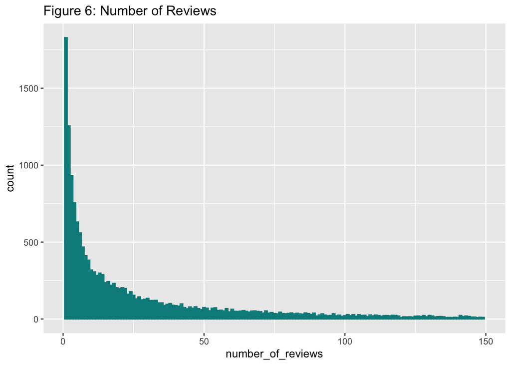

```r
ggplot(df1, aes(x=number_of_reviews)) +
  geom_histogram(color="darkcyan", fill="darkcyan", binwidth = 1) +
  ggtitle("Figure 6: Number of Reviews")
```

### Scatter Plot: ln_Price vs number_of_reviews

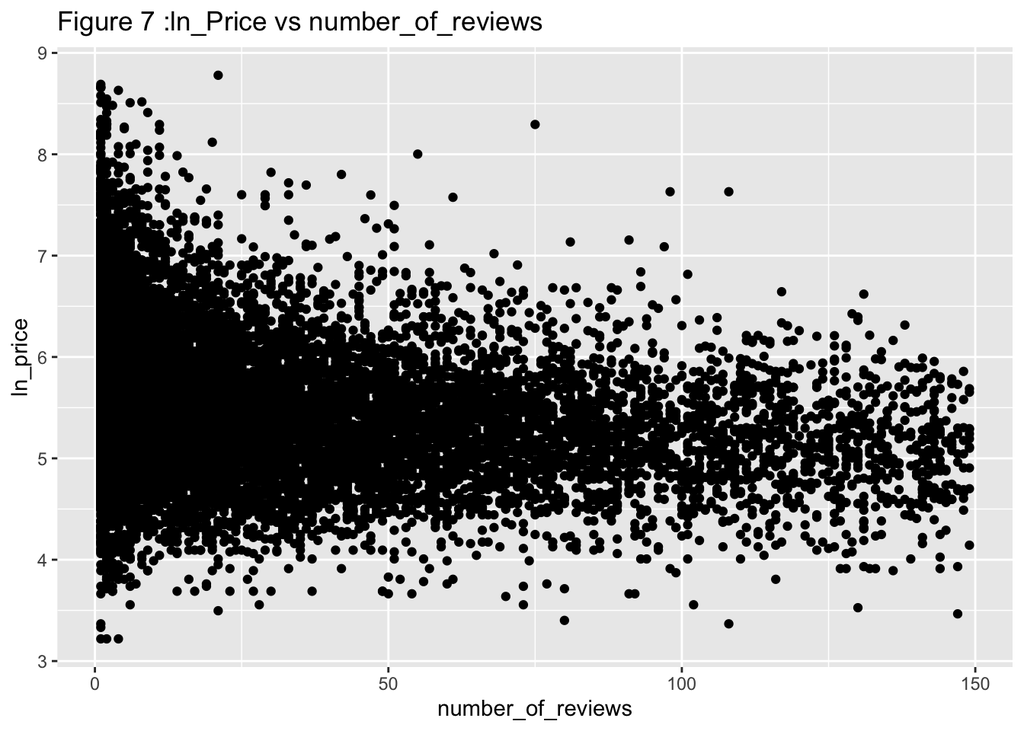

```r
ggplot(df1, aes(x=number_of_reviews, y=ln_price)) +
  geom_point() +
  ggtitle("Figure 7 :ln_Price vs number_of_reviews ")
```

##Analyzing reviews_per_month The Max reviews is 21, while the 3rd quartile is 1.7 reviews. This doesn’t seem to be related to the ln_price.

```r
summary(df$reviews_per_month)
```

```
##    Min. 1st Qu.  Median    Mean 3rd Qu.    Max.
##   0.010   0.300   0.795   1.196   1.700  21.210
```

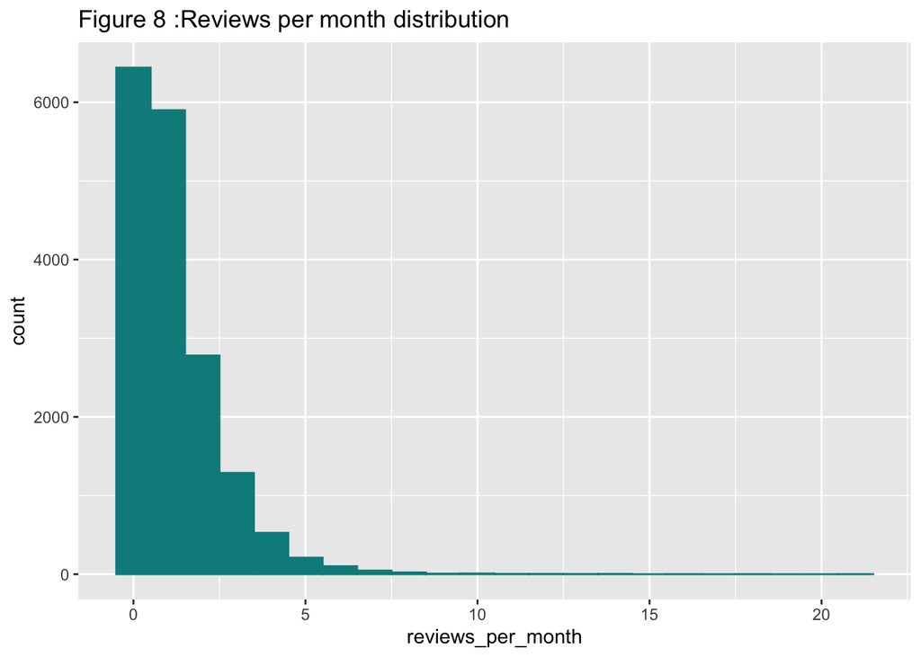

```r
ggplot(df, aes(x=reviews_per_month, color = eviews_per_month )) +
  geom_histogram(color="darkcyan", fill="darkcyan", binwidth = 1) +
  ggtitle("Figure 8 :Reviews per month distribution")
```

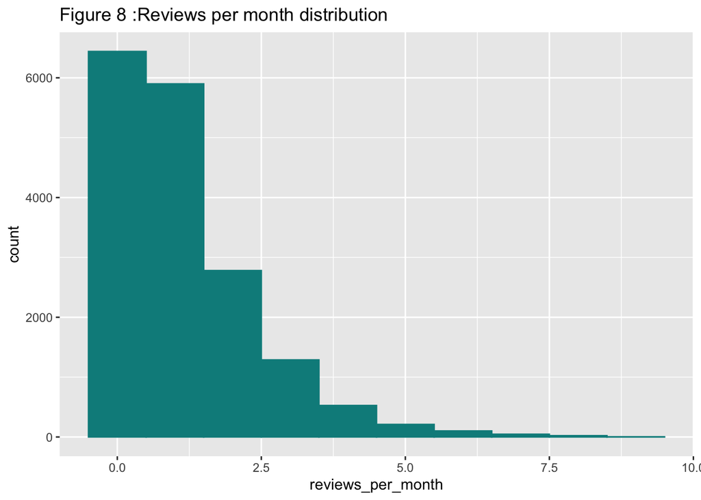

```r
df1 <- subset(df, reviews_per_month < 9)

ggplot(df1, aes(x=reviews_per_month)) +
  geom_histogram(color="darkcyan", fill="darkcyan", binwidth = 1) +
  ggtitle("Figure 8 :Reviews per month distribution")
```

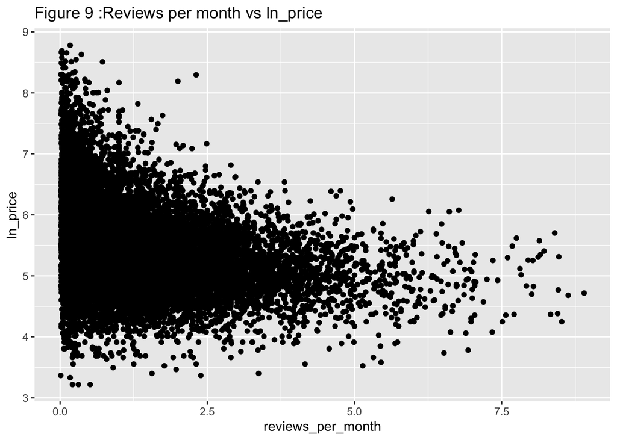

```r
ggplot(df1, aes(x=reviews_per_month, y=ln_price)) +
  geom_point() +
  ggtitle("Figure 9 :Reviews per month vs ln_price")
```

## Analyzing calculated_host_listings_count

```r
summary(df$calculated_host_listings_count)
```

```
##    Min. 1st Qu.  Median    Mean 3rd Qu.    Max.
##     1.0     2.0    10.0    58.3    69.0   439.0
```

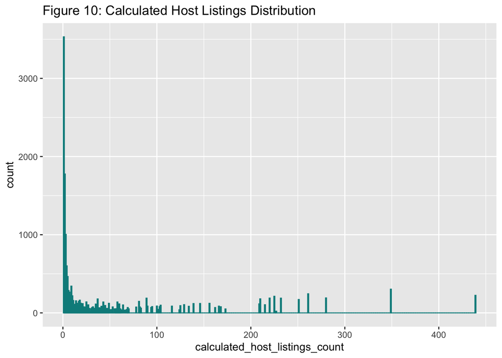

```r
ggplot(df, aes(x=calculated_host_listings_count)) +
  geom_histogram(color="darkcyan", fill="darkcyan", binwidth = 1)+
  ggtitle("Figure 10: Calculated Host Listings Distribution")
```

```r
# df1 <- subset(df, calculated_host_listings_count > 1 &calculated_host_listings_count < 7)
df1 <- subset(df, calculated_host_listings_count > 1 &calculated_host_listings_count < 7)
```

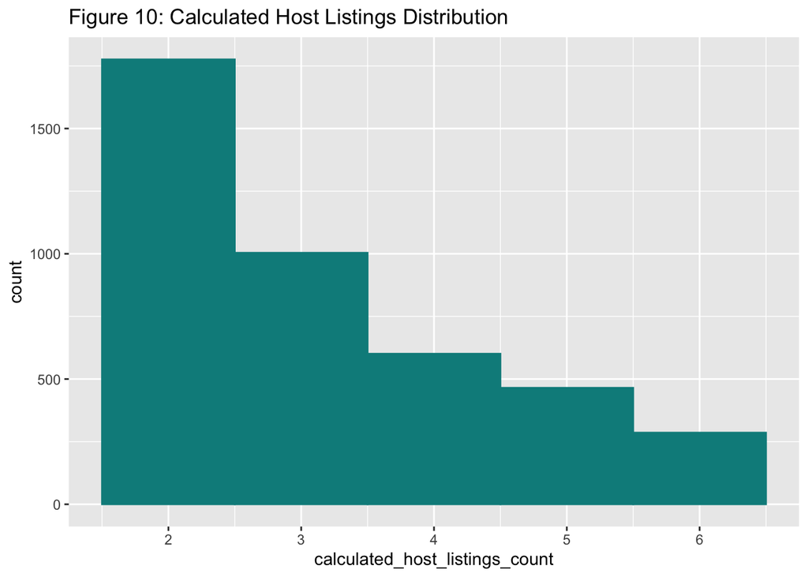

```r
ggplot(df1, aes(x=calculated_host_listings_count)) +
  geom_histogram(color="darkcyan", fill="darkcyan", binwidth = 1) +
  ggtitle("Figure 10: Calculated Host Listings Distribution")
```

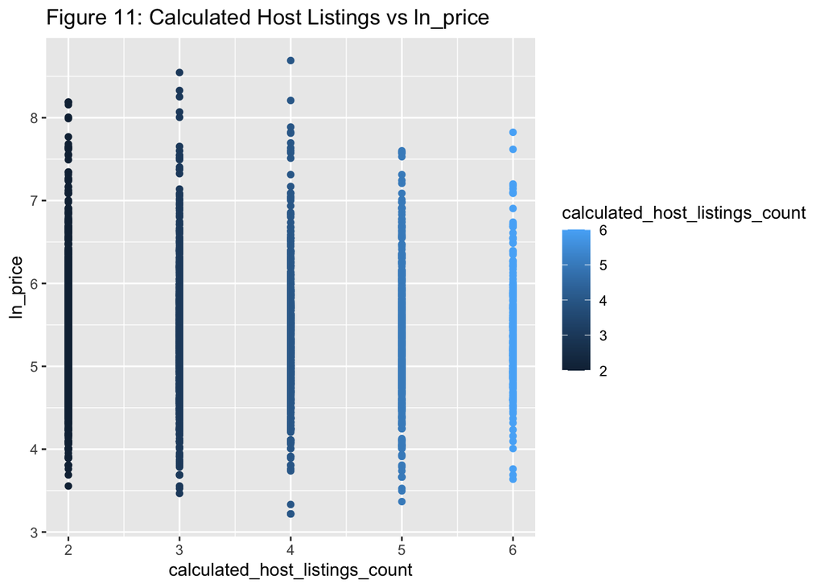

```r
ggplot(df1, aes(x=calculated_host_listings_count, y=ln_price, color = calculated_host_listings_count)) +
  geom_point() +
  ggtitle("Figure 11: Calculated Host Listings vs ln_price")
```

## Analyzing availability_365

```r
summary(df$availability_365)
```

```
##    Min. 1st Qu.  Median    Mean 3rd Qu.    Max.
##     0.0   111.0   214.0   190.5   274.0   365.0
```

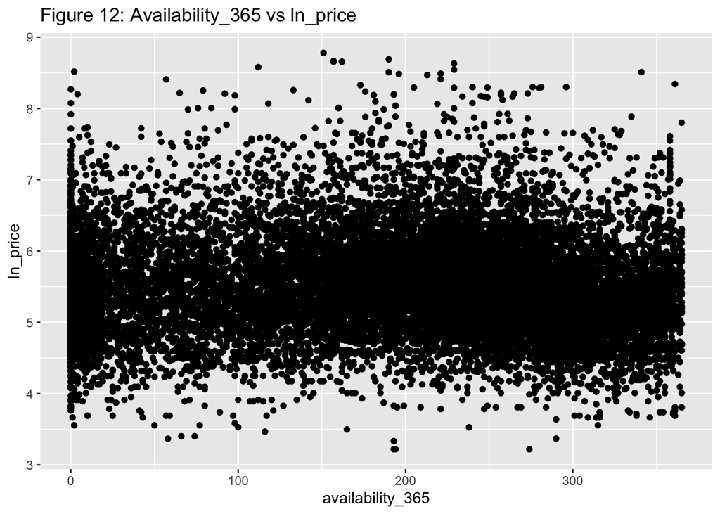

```r
ggplot(df, aes(x=availability_365, y=ln_price)) +
  geom_point() +
  ggtitle("Figure 12: Availability_365 vs ln_price")
```

```r
summary(df$number_of_reviews_ltm)
```

```
##    Min. 1st Qu.  Median    Mean 3rd Qu.    Max.
##    0.00    2.00    7.00   13.16   19.00  388.00
```

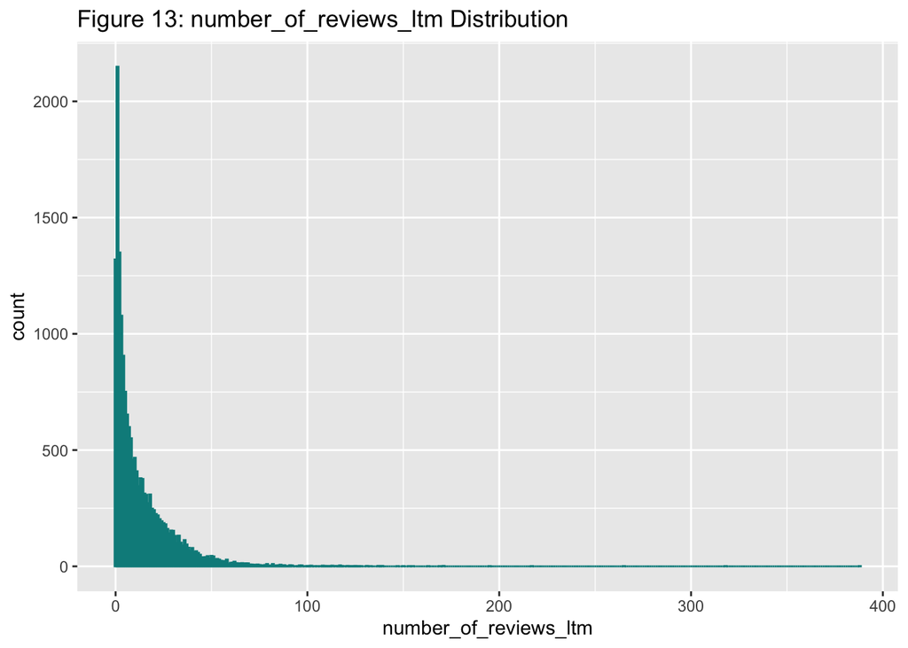

```r
ggplot(df, aes(x=number_of_reviews_ltm)) +
  geom_histogram(color="darkcyan", fill="darkcyan", binwidth = 1) +
  ggtitle("Figure 13: number_of_reviews_ltm Distribution ")
```

```r
df1 <- subset(df, number_of_reviews_ltm < 100)
```

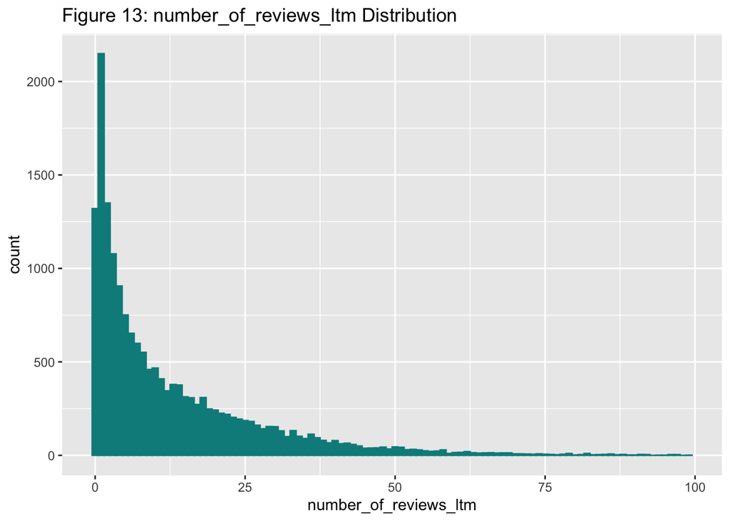

```r
ggplot(df1, aes(x=number_of_reviews_ltm)) +
  geom_histogram(color="darkcyan", fill="darkcyan", binwidth = 1) +
  ggtitle("Figure 13: number_of_reviews_ltm Distribution ")
```

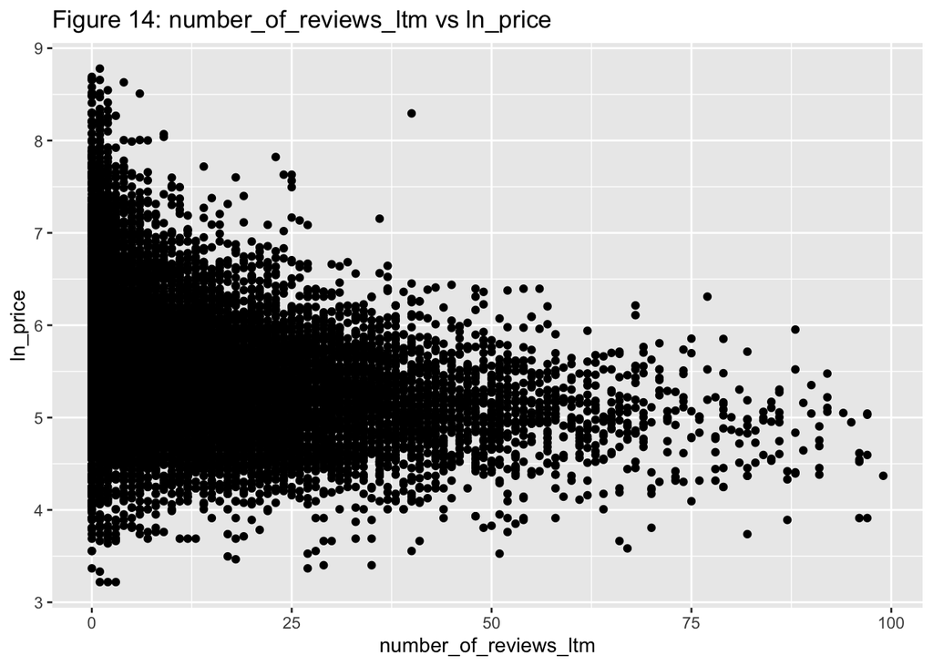

```r
ggplot(df1, aes(x=number_of_reviews_ltm, y=ln_price)) +
  geom_point() +
  ggtitle("Figure 14: number_of_reviews_ltm vs ln_price")
```

## Analyzing neighbourhood_group

There are 4 neighboring groups : Hawaii, Honolulu, Kauai, and Maui. Maui has the most observations, while Kauai with the least. There seems to be difference in prices based on neighbourhood_group: Honolulu has least and Kauai has the highest Thers is a significant difference in ln_prices based on neighbourhood_group.

```r
summary(df$neighbourhood_group)
```

```
##   Hawaii Honolulu    Kauai     Maui
##     4291     3940     2642     6473
```

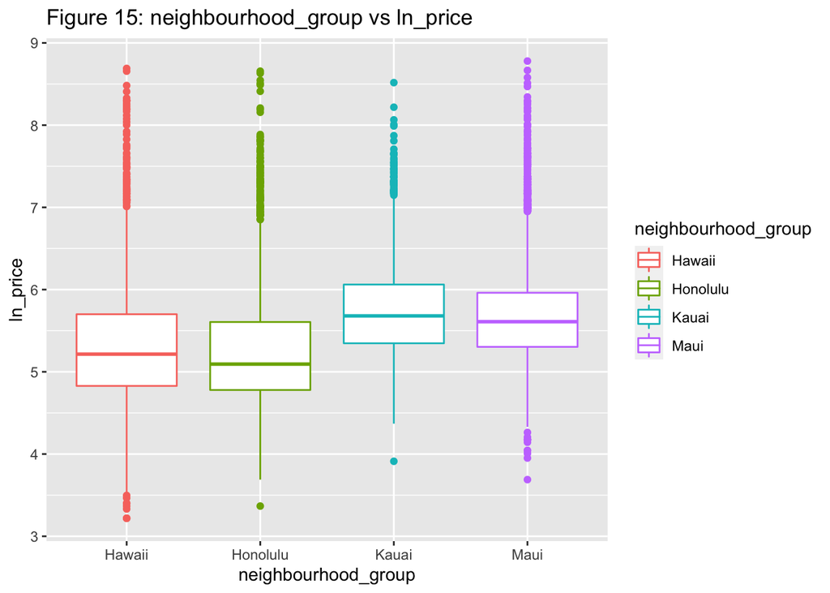

```r
ggplot(df, aes(x=neighbourhood_group, y=ln_price, color = neighbourhood_group)) +
  geom_boxplot() +
  ggtitle("Figure 15: neighbourhood_group vs ln_price")
```

```r
ANOVAln_price_neighbourhood_group <- aov(ln_price ~ neighbourhood_group, data = df)

summary(ANOVAln_price_neighbourhood_group)
```

```
##                        Df Sum Sq Mean Sq F value              Pr(>F)
## neighbourhood_group     3    839  279.81   672.4 <0.0000000000000002 ***
## Residuals           17342   7217    0.42
## ---
## Signif. codes:  0 '***' 0.001 '**' 0.01 '*' 0.05 '.' 0.1 ' ' 1
```

# Analyzing license

Checking the relationship between ln_price and license, there is no difference.

```r
summary(df$license)
```

```
##     0     1
##  3134 14212
```

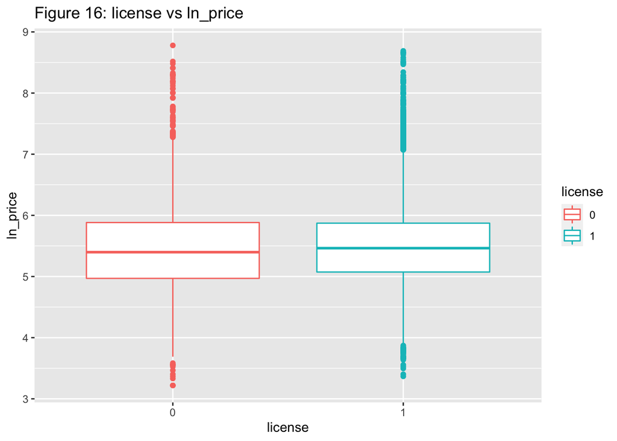

```r
ggplot(df, aes(x=license, y=ln_price, color = license)) +
  geom_boxplot() +
  ggtitle("Figure 16: license vs ln_price")
```

## Analyzing room_type

```r
summary(df$room_type)
```

```
## Entire home/apt      Hotel room    Private room     Shared room
##           15970              75            1273              28
```

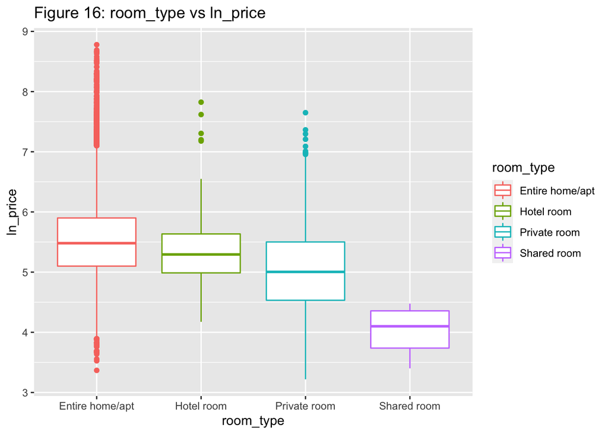

```r
ggplot(df, aes(x=room_type, y=ln_price, color = room_type)) +
  geom_boxplot() +
 ggtitle("Figure 16: room_type vs ln_price")
```

```r
ANOVAln_price_room_type <- aov(ln_price ~ room_type, data = df)
summary(ANOVAln_price_room_type)
```

```
##                Df Sum Sq Mean Sq F value              Pr(>F)
## room_type       3    336  112.06   251.7 <0.0000000000000002 ***
## Residuals   17342   7720    0.45
## ---
## Signif. codes:  0 '***' 0.001 '**' 0.01 '*' 0.05 '.' 0.1 ' ' 1
```

## Pearson Correlation: Numeric independent variables with Price

Correlation is very low between numeric variables and dependent variable.

```r
## Get the list of the categorical data

categoricalList = names(df %>% select(where(is.factor)) %>% glimpse())
```

```
## Rows: 17,346
## Columns: 5
## $ neighbourhood_group <fct> Hawaii, Hawaii, Hawaii, Kauai, Kauai, Maui, Hawaii…
## $ neighbourhood       <fct> South Kohala, South Kona, North Kona, North Shore …
## $ minimum_nights      <fct> 3, 5, 6, 2, 3, 4, 3, 3, 7, 1, 3, 2, 7, 3, 3, 1, 1,…
## $ license             <fct> 1, 0, 0, 1, 1, 1, 1, 1, 1, 1, 1, 1, 0, 1, 1, 1, 1,…
## $ room_type           <fct> Entire home/apt, Entire home/apt, Entire home/apt,…
```

```r
## getting list of the non categorical data, which will be numeric or int

numericList = names(df)[!names(df) %in% categoricalList]

cor(df[,numericList])
```

```
##                                      price number_of_reviews reviews_per_month
## price                           1.00000000      -0.183555451      -0.230434594
## number_of_reviews              -0.18355545       1.000000000       0.626904798
## reviews_per_month              -0.23043459       0.626904798       1.000000000
## calculated_host_listings_count  0.09226919      -0.264602884      -0.284560816
## availability_365               -0.03565297       0.007697643      -0.003428713
## number_of_reviews_ltm          -0.20793781       0.729098169       0.797214939
## ln_price                        0.80975916      -0.278601516      -0.326656268
##                                calculated_host_listings_count availability_365
## price                                              0.09226919     -0.035652968
## number_of_reviews                                 -0.26460288      0.007697643
## reviews_per_month                                 -0.28456082     -0.003428713
## calculated_host_listings_count                     1.00000000      0.192246447
## availability_365                                   0.19224645      1.000000000
## number_of_reviews_ltm                             -0.27368292      0.013176587
## ln_price                                           0.17299087     -0.049290780
##                                number_of_reviews_ltm    ln_price
## price                                    -0.20793781  0.80975916
## number_of_reviews                         0.72909817 -0.27860152
## reviews_per_month                         0.79721494 -0.32665627
## calculated_host_listings_count           -0.27368292  0.17299087
## availability_365                          0.01317659 -0.04929078
## number_of_reviews_ltm                     1.00000000 -0.29111212
## ln_price                                 -0.29111212  1.00000000
```

## Working with the Selected Variables

```r
df = df[,c('ln_price','room_type','neighbourhood_group','minimum_nights')]

names(df)
```

```
## [1] "ln_price"            "room_type"           "neighbourhood_group"
## [4] "minimum_nights"
```

## Train Test data division 80-20: create a holdout set (20% of observations)

```r
set.seed(100)
n = nrow(df)
trainIndex = sample(1:n, size = round(0.8*n), replace=FALSE)
train = df[trainIndex ,]
test = df[-trainIndex ,]
```

```r
Formula1 = as.formula(ln_price~room_type)
Formula2 = as.formula(ln_price~neighbourhood_group)
Formula3 = as.formula(ln_price~minimum_nights)

Formula4 = as.formula(ln_price~room_type+neighbourhood_group)
Formula5 = as.formula(ln_price~room_type+minimum_nights)
Formula6 = as.formula(ln_price~neighbourhood_group+minimum_nights)

Formula7 = as.formula(ln_price~neighbourhood_group+minimum_nights+room_type)

FormulaList = c(Formula1,Formula2,Formula3,Formula4,Formula5,Formula6,Formula7)
```

## Linear modeling : lm

```r
Results = data.frame()
TestDataAccuracyAlldata = data.frame()
TestDataAccuracyAlldataK = data.frame()

for ( i in 1:7 ){

  formula <- as.formula( unlist( FormulaList[[i]] ))

  # running the model on entire data set
  model_work_data <- feols( formula , data = train , vcov='hetero' )


  fs  <- fitstat(model_work_data,c('rmse','r2','bic'))
  BIC <- fs$bic
  r2  <- fs$r2
  rmse_train <- fs$rmse
  ncoeff <- length( model_work_data$coefficients )

  # Do the k-fold cross validation with 5 folds

  cv_i <- train( formula, train, method = "lm",
                 trControl = trainControl(method = "cv", number = 5))

  rmse_k <- mean( cv_i$resample$RMSE )

  # Save the results
  TempResults = data.frame(Model = paste("Model",i),
                           Formula = as.character(( FormulaList[i] )),
                           Coefficients=ncoeff,
                           R_squared=r2,
                           BIC = BIC,
                           RMSE_Train = rmse_train,
                           RMSE_K_Fold = rmse_k
                           )

  ### External Validity

  ## LM Robust Model performance on test data

  ## Model performance on test data

  test$PredictM1R = predict(model_work_data,test)
  ACCR = accuracy(test$PredictM1R,test$ln_price)

  TempTestDataAccuracyAlldata = data.frame(Model = c(paste('Model',i)),
                                         ME = c(ACCR[1]),
                                         RMSE = c(ACCR[2]),
                                         MAE = c(ACCR[3]),
                                         MPE = c(ACCR[4]),
                                         MAPE = c(ACCR[5])
                                         )

  test$PredictM1R = predict(cv_i,test)
  ACCR = accuracy(test$PredictM1R,test$ln_price)

  TempTestDataAccuracyAlldataK = data.frame(Model = c(paste('Model_K',i)),
                                         ME = c(ACCR[1]),
                                         RMSE = c(ACCR[2]),
                                         MAE = c(ACCR[3]),
                                         MPE = c(ACCR[4]),
                                         MAPE = c(ACCR[5])
                                         )

  TestDataAccuracyAlldata = rbind(TestDataAccuracyAlldata ,TempTestDataAccuracyAlldata )
  TestDataAccuracyAlldataK = rbind(TestDataAccuracyAlldataK ,TempTestDataAccuracyAlldataK )

  Results = rbind(Results,TempResults)
}



rownames(Results) <- NULL
Results
```

| Model | Formula | Coefficients | R_squared | BIC | RMSE_Train | RMSE_K_Fold |
| --- | --- | --- | --- | --- | --- | --- |
| Model 1 | ln_price ~ room_type | 4 | 0.0437 | 2.82e+04 | 0.669 | 0.669 |
| Model 2 | ln_price ~ neighbourhood_group | 4 | 0.108 | 2.73e+04 | 0.646 | 0.646 |
| Model 3 | ln_price ~ minimum_nights | 8 | 0.0868 | 2.76e+04 | 0.653 | 0.654 |
| Model 4 | ln_price ~ room_type + neighbourhood_group | 7 | 0.136 | 2.69e+04 | 0.635 | 0.636 |
| Model 5 | ln_price ~ room_type + minimum_nights | 11 | 0.121 | 2.71e+04 | 0.641 | 0.641 |
| Model 6 | ln_price ~ neighbourhood_group + minimum_nights | 11 | 0.164 | 2.64e+04 | 0.625 | 0.626 |
| Model 7 | ln_price ~ neighbourhood_group + minimum_nights + room_type | 14 | 0.189 | 2.61e+04 | 0.616 | 0.617 |

## All data Model Performance on test data

```r
TestDataAccuracyAlldata
```

| Model | ME | RMSE | MAE | MPE | MAPE |
| --- | --- | --- | --- | --- | --- |
| Model 1 | 0.007 | 0.662 | 0.507 | -1.26 | 9.23 |
| Model 2 | 0.00331 | 0.642 | 0.487 | -1.23 | 8.82 |
| Model 3 | 0.000546 | 0.647 | 0.499 | -1.32 | 9.12 |
| Model 4 | 0.00461 | 0.634 | 0.482 | -1.16 | 8.71 |
| Model 5 | 0.00176 | 0.639 | 0.494 | -1.24 | 8.98 |
| Model 6 | -0.000969 | 0.624 | 0.475 | -1.23 | 8.61 |
| Model 7 | 0.000193 | 0.617 | 0.472 | -1.16 | 8.53 |

## k folds Model Performance on test data

```r
TestDataAccuracyAlldataK
```

| Model | ME | RMSE | MAE | MPE | MAPE |
| --- | --- | --- | --- | --- | --- |
| Model_K 1 | 0.007 | 0.662 | 0.507 | -1.26 | 9.23 |
| Model_K 2 | 0.00331 | 0.642 | 0.487 | -1.23 | 8.82 |
| Model_K 3 | 0.000546 | 0.647 | 0.499 | -1.32 | 9.12 |
| Model_K 4 | 0.00461 | 0.634 | 0.482 | -1.16 | 8.71 |
| Model_K 5 | 0.00176 | 0.639 | 0.494 | -1.24 | 8.98 |
| Model_K 6 | -0.000969 | 0.624 | 0.475 | -1.23 | 8.61 |
| Model_K 7 | 0.000193 | 0.617 | 0.472 | -1.16 | 8.53 |

```r
write.csv(TestDataAccuracyAlldataK,"TestData.csv",row.names = FALSE)
```

## Alternative model LASSO

```r
# Set lasso tuning parameters:

# a) basic setup
train_control <- trainControl( method = "cv", number = 5)

# b) tell the actual lambda (penalty parameter) to use for lasso
tune_grid     <- expand.grid("alpha" = c(1), "lambda" = seq(0.05, 1, by = 0.05))



# Run LASSO

lasso_model <- train(ln_price ~.,
                            data = train,
                            method = "glmnet",
                            preProcess = c("center", "scale"),
                            trControl = trainControl( method = "cv", number = 5),
                            tuneGrid = tune_grid,
                            na.action=na.exclude)


# One can get the coefficients as well
lasso_coeffs <- coef(lasso_model$finalModel, lasso_model$bestTune$lambda) %>%
  as.matrix() %>%
  as.data.frame() %>%
  rownames_to_column(var = "variable") %>%
  rename(coefficient = `s1`)  # the column has a name "1", to be renamed


# Check the number of variables which actually has coefficients other than 0
lasso_coeffs_nz<-lasso_coeffs %>%
  filter(coefficient!=0)


# Get the RMSE of the Lasso model
#   Note you should compare this to the test RMSE
lasso_fitstats <- lasso_model$results %>%
  filter(lambda == lasso_model$bestTune$lambda)
lasso_fitstats
```

| alpha | lambda | RMSE | Rsquared | MAE | RMSESD | RsquaredSD | MAESD |
| --- | --- | --- | --- | --- | --- | --- | --- |
| 1 | 0.05 | 0.634 | 0.168 | 0.484 | 0.00509 | 0.0171 | 0.00334 |

### results of lasso model

```r
lasso_add <- data.frame(Model='LASSO', Coefficients=nrow(lasso_coeffs_nz),
                    Formula = "ln_price ~.",
                    R_squared=lasso_fitstats$Rsquared, BIC = NA,
                    RMSE_Train = NA, RMSE_K_Fold = lasso_fitstats$RMSE )

lasso_add
```

| Model | Coefficients | Formula | R_squared | BIC | RMSE_Train | RMSE_K_Fold |
| --- | --- | --- | --- | --- | --- | --- |
| LASSO | 11 | ln_price ~. | 0.168 |  |  | 0.634 |

### Adding it to previous results

```r
Results <- rbind( Results , lasso_add )
rownames(Results) <- NULL
Results
```

| Model | Formula | Coefficients | R_squared | BIC | RMSE_Train | RMSE_K_Fold |
| --- | --- | --- | --- | --- | --- | --- |
| Model 1 | ln_price ~ room_type | 4 | 0.0437 | 2.82e+04 | 0.669 | 0.669 |
| Model 2 | ln_price ~ neighbourhood_group | 4 | 0.108 | 2.73e+04 | 0.646 | 0.646 |
| Model 3 | ln_price ~ minimum_nights | 8 | 0.0868 | 2.76e+04 | 0.653 | 0.654 |
| Model 4 | ln_price ~ room_type + neighbourhood_group | 7 | 0.136 | 2.69e+04 | 0.635 | 0.636 |
| Model 5 | ln_price ~ room_type + minimum_nights | 11 | 0.121 | 2.71e+04 | 0.641 | 0.641 |
| Model 6 | ln_price ~ neighbourhood_group + minimum_nights | 11 | 0.164 | 2.64e+04 | 0.625 | 0.626 |
| Model 7 | ln_price ~ neighbourhood_group + minimum_nights + room_type | 14 | 0.189 | 2.61e+04 | 0.616 | 0.617 |
| LASSO | ln_price ~. | 11 | 0.168 |  |  | 0.634 |

```r
write.csv(Results,"Results.csv",row.names = FALSE)
```

### BIC results

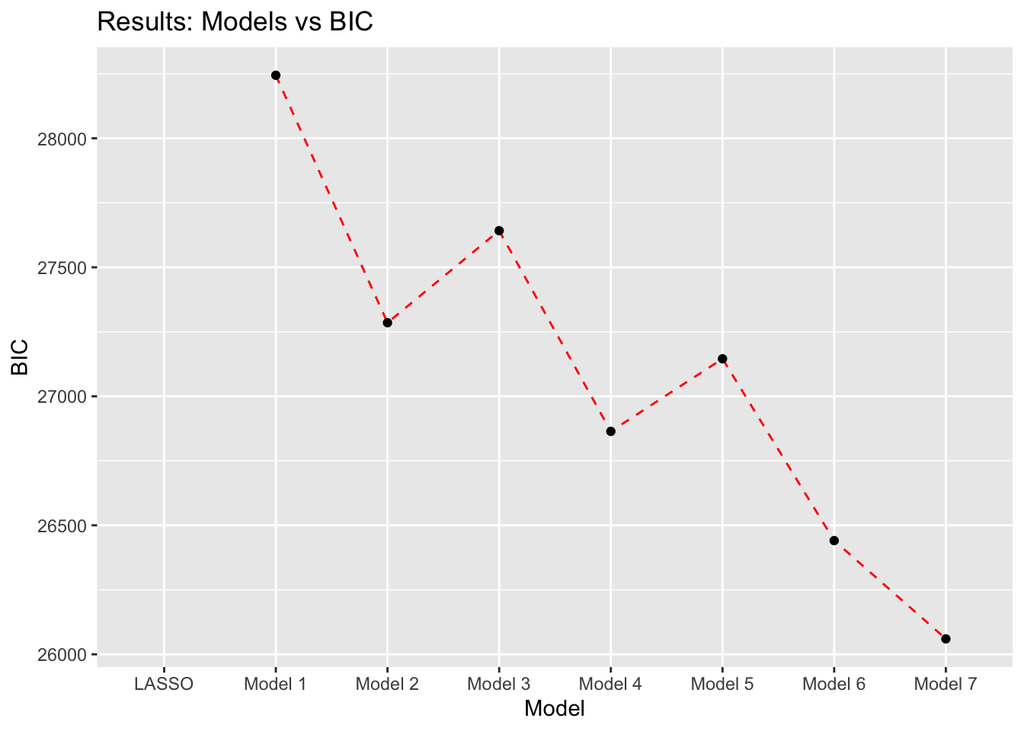

```r
ggplot(Results, aes(x=Model, y=BIC, group=1)) +
  geom_line(color="red",linetype = "dashed")+
  geom_point() +
  ggtitle("Results: Models vs BIC")
```

Model 7 has the lowest BIC so it should be used

### RMSE_Train results

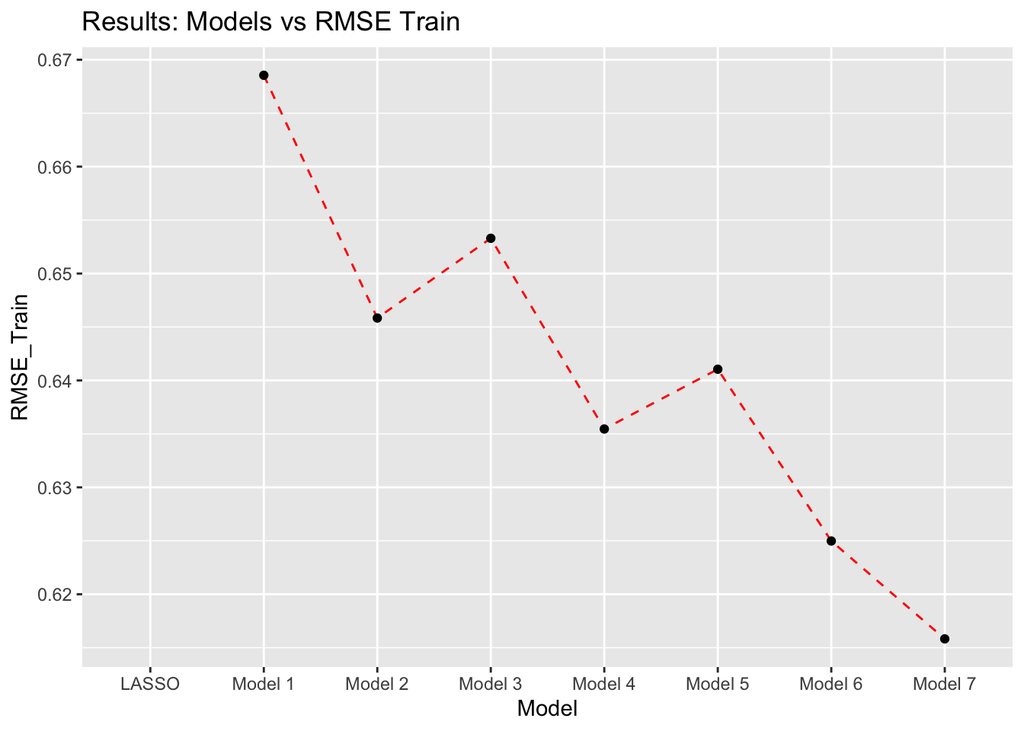

```r
ggplot(Results, aes(x=Model, y=RMSE_Train, group=1)) +
  geom_line(color="red",linetype = "dashed")+
  geom_point() +
  ggtitle("Results: Models vs RMSE Train")
```

### RMSE_K_Fold results

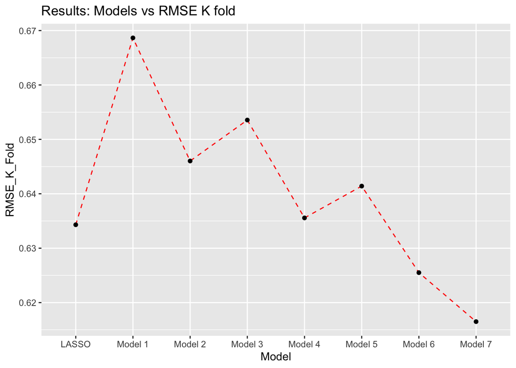

```r
ggplot(Results, aes(x=Model, y=RMSE_K_Fold, group=1)) +
  geom_line(color="red",linetype = "dashed")+
  geom_point() +
  ggtitle("Results: Models vs RMSE K fold")
```

Model 7 has the lowest RMSE, less than lasso as well, So BIC and RMSE both suggest Model 7 is best

## Model Performance on test data: RMSE results

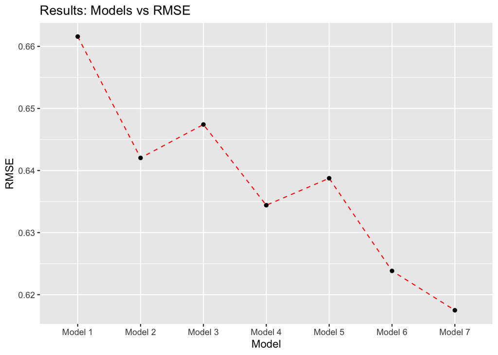

```r
ggplot(TestDataAccuracyAlldata, aes(x=Model, y=RMSE, group=1)) +
  geom_line(color="red",linetype = "dashed")+
  geom_point() +
  ggtitle("Results: Models vs RMSE")
```

Model 7 performs better on test data as well.